# derek_questions_june_15

Don Radcliffe

6/14/2021

This markdown script is intended to facilitate our meeting on Tuesday, June 15th, by providing an easy place to share questions and data in the same space. The first section takes a look at the Colville dataset with an eye towards the funding questions you may have, and the second section offers alternate presentations of the meta-analysis data for the report.

# Colville

```r
## Colville Data
raw_cnf_trees <- read.csv(file.path(import_dir_cnf, 'trees_tidy.csv'))
cnf_plot_info <- read.csv(file.path(import_dir_cnf, 'plot_info.csv'))

cnf_trees <- raw_cnf_trees %>%
  full_join(cnf_plot_info, by = c('plot')) %>%
  ## Filter dead tree data out of my portion, not sure if Clark & Loehman included it.
  filter(status != 'dead') %>%
  ## Not all commercial thin labelled the same way,
  ## and changing 'shelterwood establishment cut' to 'shelterwood' so it's less clunky in the legend.
  mutate(treatment_type = str_replace_all(treatment_type, c(
    'commercial thin' = 'commercial',
    'commercial' = 'commercial thin',
    'shelterwood establishment cut' = 'shelterwood'))) %>%
  ## Factor in a logical order.
  mutate(treatment_type = factor(treatment_type, levels = c(
    'commercial thin', 'shelterwood', 'clearcut'
  )))
```

Some graphing standardization:

```r
## Theme for graphing.
simpletheme <- theme(panel.grid.major = element_blank(),
                     panel.grid.minor = element_blank(),
                     panel.background = element_blank()) +
  theme(plot.title = element_text(hjust = 0.5)) +
  theme(axis.line = element_line(size = 0.2, color = 'black')) +
  theme(legend.key=element_blank(), legend.background=element_blank(), legend.title = element_blank()) +
  theme(legend.position = 'bottom')

treatment_type_colors <- c('commercial thin' = 'blue1',
                           'shelterwood' = 'green1',
                           'clearcut' = 'gray50')
```

## Graphs

Below I graph basal area against time since treatment, as a visual example of our Colville study so we can talk about where we could fill in the study design. We’ve got 79 plots here that meet our criteria of being a thin+burn treatment in a dry forest, and what’s not included here that can be included in the Colville study is at least 50 ‘control’ plots: those pretreatment plots from the East Wedge and Walker projects that don’t overlap with any treatments recorded in the FACTS database.

I received plot-level-summarized data from Jason Clark, so unfortunately I can’t be 100% sure that I processed my data in the exact same way. The Colville tree graphs are for trees greater than five inches.

The first graph below gives the best idea of the timespread, the second graph below is faceted by project area and gives a better idea of spatial clustering. Note that the colors denote which type of thinning ‘treatment’ and don’t include the word burn, because all were burned.

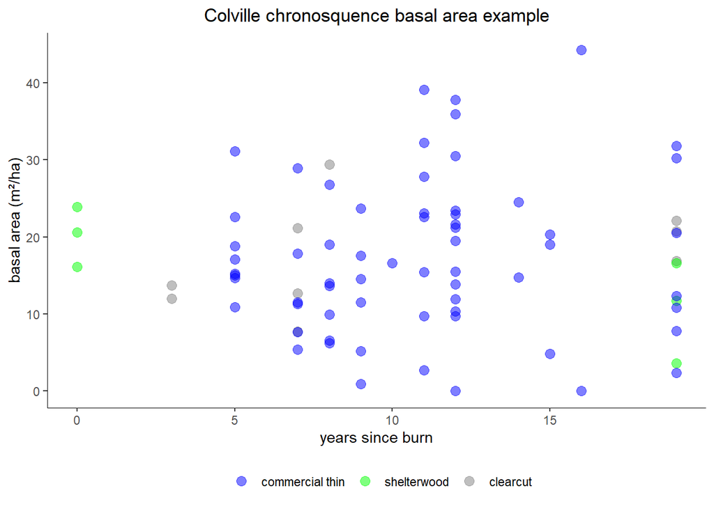

```r
ba_all <- cnf_trees %>%
  ggplot(aes(x = years_post, y = basal_area, color = treatment_type)) +
    geom_point(size = 3, alpha = 0.5) +
    ggtitle('Colville chronosquence basal area example') +
    xlab('years since burn') +
    ylab('basal area (m²/ha)') +
    scale_color_manual(values = treatment_type_colors) +
    simpletheme
ba_all
```

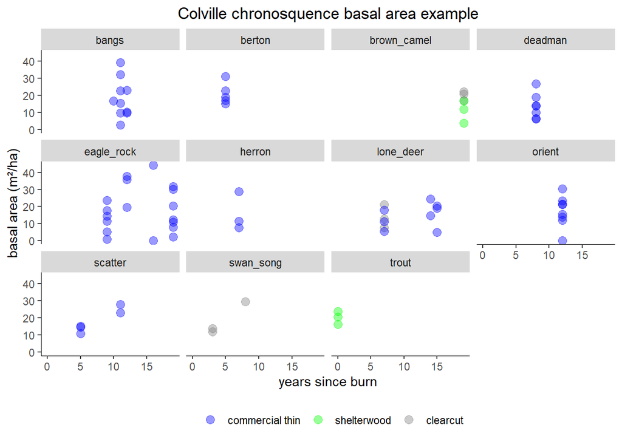

```r
ba_facet <- cnf_trees %>%
  ggplot(aes(x = years_post, y = basal_area, color = treatment_type)) +
    geom_point(size = 3, alpha = 0.4) +
    facet_wrap(vars(project)) +
    ggtitle('Colville chronosquence basal area example') +
    xlab('years since burn') +
    ylab('basal area (m²/ha)') +
    scale_color_manual(values = treatment_type_colors) +
    simpletheme
ba_facet
```

## Thoughts on Colville data needs.

There looks to be a pretty weak relationship of basal area with time, which matches my expectations after fieldwork. I’d expect many fuels metrics to be even more variable if anything. For the manuscript we’ll probably need to bring in a site productivity index and thinning intensity estimate to help us sort things out. It would be pretty interesting for the longevity question if we found that productivity explained more variance than time.

For publication purposes, I think we should aim fairly low with the chronosequence design unless we have a ton of plots and stands. With some extra funding for a couple weeks field work, I see four possible strategies for improving the publishability of the data with more field plots:

1. Sample more plots in the short term (0-5 year) interval.
2. Sample more plots in the long term (15+ year) interval.
3. Get better representation of project areas.
4. Get plots from a different treatment category, like thinning only.

Just in looking at the temporal spread, I see option 1 as most likely to improve the study, easiest to sell to funders, and as most achievable. Without a decent sample size in the short term, we don’t have much to compare all those mid-term plots to (although, there will be many ‘control’ plots which will help our case). Since most knowledge about fuels treatment is based on short term sampling, it would be valuable to have some ‘anchor points’ there. From a logistics standpoint, it’d be pretty easy to ask Eric, James, and Jason where the recent treatments are happening, and I know they are happening both from seeing it and from the FACTS database. This would also have the advantage of adding more project areas (option 3). There seems to be a greater prevalence of jackpot burning (as opposed to broadcast) in more recent projects, but some of the Clark/Loemann plots and a few of mine had jackpot burning, so we already have that as part of the study.

We could also add a few more long term plots (option 2), but we would only be able to pull from project areas already represented, especially Eagle Rock. We’ve sampled from all the feasible project areas in the west Colville. Here’s the map if you need a memory jog:

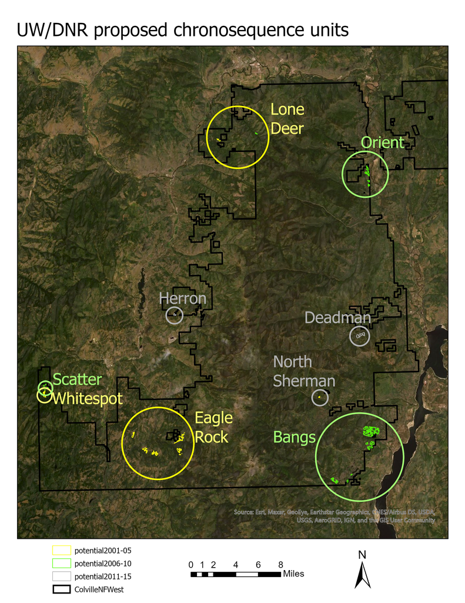

For getting better representation of project areas, there would be two ways to go: adding shorter term data, or going to a different district or ownership. A quick check of the FACTs database showed relatively few thin+burn projects on other districts, but there are some on the Three Rivers Ranger District, which we could look deeper into. It’s also worth considering the adjacent Sherman Creek Wildlife Area, which has done a lot of treatment and isn’t in the FACTS database.

I wanted to put other treatments out there as an idea, but I think it’s probably best to intensify the sample of one treatment type so we can maximize the value for testing the effect of time. I think the forest is too variable and the chronosequence design too weak for us to afford splitting treatments.

## Funding Proposal and Budget

I can easily see the value of an additional 15-20 short term plots and a few additional long term plots, and propose that as a plan for the fuels survey.

For the bird survey, work would be roughly early May through Late June. Brian told me that DNR money would need to be spent by June 30, 2022, so the fuels work would run about the same timeline.

During that timeline in an ideal world, I’d have six crewmembers including me: four for bird work, and two for chronosequence. Based on the numbers that Brian gave me, it looks like four people total is more reasonable, but let me know if more seems feasible. Below is a budget for four people for eight weeks, which is about as long as our part of the work could go. It’s actually a little high because I divided the monthly rate by four to get a weekly estimate. We could also budget for seven weeks if it’s too much.

- Field techs salary and benefits: 800/week * 4 techs = $3,200/week
- Food and lodging: 125/week * 4 techs = $ 500/week
- Ucars: 600/week * 2 cars = $1,200/week
- Total weekly: = $4,900/week
- Gear: $2,000
- **Total for 8 weeks: $41,200**

I’m proposing that we spend about 8 person weeks, or 2/8 full crew weeks, filling out the chronosequence work with mostly shorter term plots. That should get us in the ballpark of 20 plots, depending on crew experience. Likely, one team of two would do most of the chronosequence work, and I would spend most my time on the bird work since I’m designing the biodiversity/fuels treatment synergy/tradeoff study and including it in my dissertation.

Brian also mentioned that you may be open to funding some RA money for me, and I appreciate you bringing this up as an option. So you know where I’m at: this would be very helpful for the summer term of 2022 and 2023 if possible in the future; I know the money in question right now is only up to the end of the next fiscal year so it doesn’t apply to those terms. Not having to do fieldwork in the summer would go a long way towards freeing up time to work through the datasets we’ve compiled for the fuels longevity project, including the Colville chronosequence. For the academic year quarters, I currently have fellowship funding for another couple of years and need to save some quarters to get teaching experience.

# Metaanlysis

For this section I want to present some of the alternative possibilities for graphing the meta-analysis data in the fuels longevity report, and then discuss what conclusions we can talk about from the results. I’ll use basal area as the example again because its probably the metric with the tightest relationship to the other metrics. Note that I haven’t formatted my own datasets into this table yet, so these graphs aren’t totally complete, but that will be the next step.

First, here’s a quick map of studies we’re pulling data from. I’m not sure it’s best to make a map to go in the report, because many of these studies don’t have exact locations, but I’m open to either way.

[figure not shown]

Formatting code:

```r
raw_ma <- read.csv(file.path(import_dir_ma, 'web_plot_digitizer_data.csv'))
ba_ma <- raw_ma %>%
  filter(variable == 'basal_area') %>%
  ## Proposing to keep entirely natural disturbances out of the scope of this report.
  filter(treatment != 'wildfire_low') %>%
  mutate(treatment = factor(treatment,
         levels = c('control', 'burn', 'thin', 'thinburn',
                    'control+beetle', 'burn+beetle', 'thin+beetle', 'thinburn+beetle',
                    'undifferentiated')))

## Filter out sequoia outliers.
ba_ns <- ba_ma %>%
  filter(value < 100)
```

Graphing standardization:

```r
## Theme for graphing.
simpletheme <- theme(panel.grid.major = element_blank(),
                     panel.grid.minor = element_blank(),
                     panel.background = element_blank()) +
  theme(plot.title = element_text(hjust = 0.5)) +
  theme(axis.line = element_line(size = 0.2, color = 'black')) +
  theme(legend.key=element_blank(), legend.background=element_blank())

treatment_colors <- c('control' = 'deepskyblue1',
                      'burn' = 'red3',
                      'thin' = 'gold2',
                      'thinburn' = 'purple3',
                      'control+beetle' = 'gray70',
                      'burn+beetle' = 'gray55',
                      'thin+beetle' = 'gray40',
                      'thinburn+beetle' = 'gray25',
                      'undifferentiated' = 'saddlebrown')
```

First is just the time/basal area relationship, colored by treatment.

The four basal area outliers come from Mantgem et al. 2016 California National Park mixed conifer stands, which include giant sequoia trees. I show them in this first graph but then filter them out for the others.

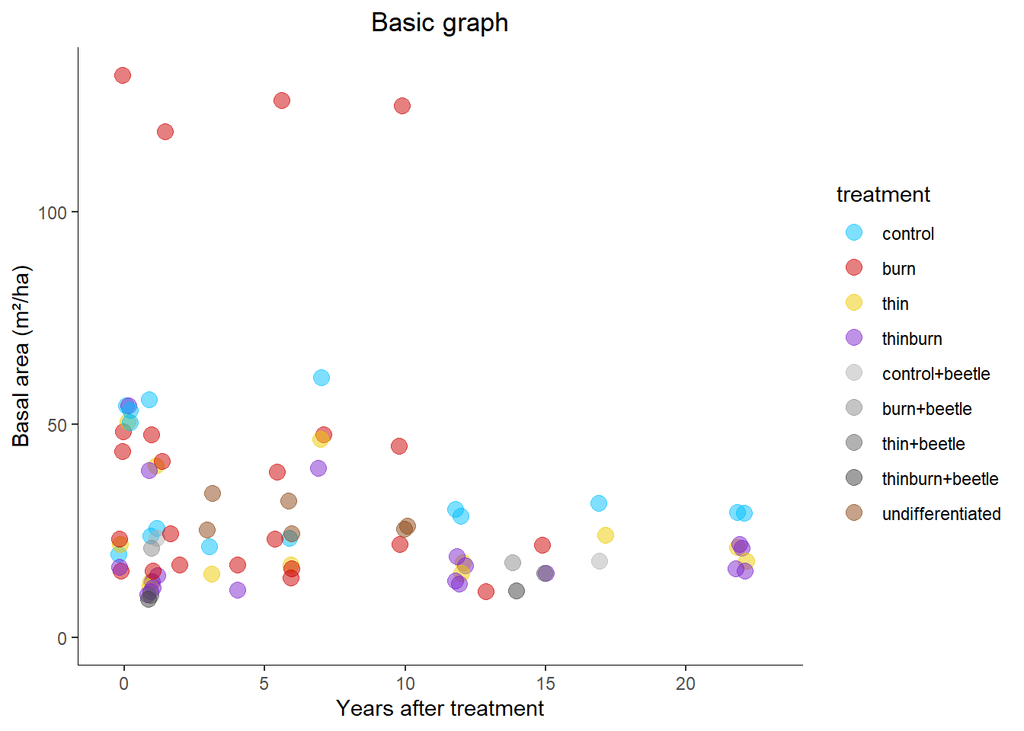

```r
ggplot(ba_ma, aes(x = years_post, y = value)) +
    geom_jitter(aes(color = treatment), size = 3.5, alpha = 0.5) +
    scale_color_manual(values = treatment_colors) +
    coord_cartesian(xlim = c(-0.5, 23)) +
    expand_limits(y = 0) +
    ggtitle('Basic graph') +
    xlab('Years after treatment') +
    ylab('Basal area (m²/ha)') +
    simpletheme
```

It may be useful to think about forest type, which gives us a predictable pattern:

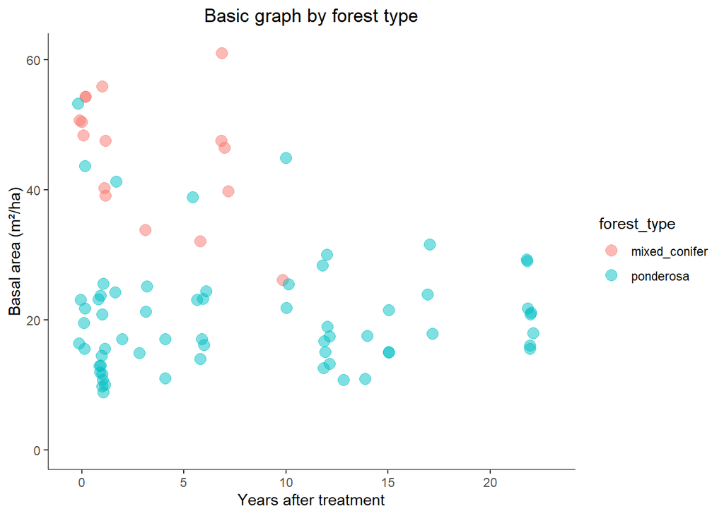

```r
ggplot(ba_ns, aes(x = years_post, y = value)) +
    geom_jitter(aes(color = forest_type), size = 3.5, alpha = 0.5) +
    #scale_color_manual(values = treatment_colors) +
    coord_cartesian(xlim = c(-0.5, 23)) +
    expand_limits(y = 0) +
    ggtitle('Basic graph by forest type') +
    xlab('Years after treatment') +
    ylab('Basal area (m²/ha)') +
    simpletheme
```

Or we could color by region, which helps sort out possible confounding of higher productivity, shorter term studies from the Sierra with decreasing basal area with time. Following the blue interior pnw plots, for example, it appears basal area increases with time as expected.

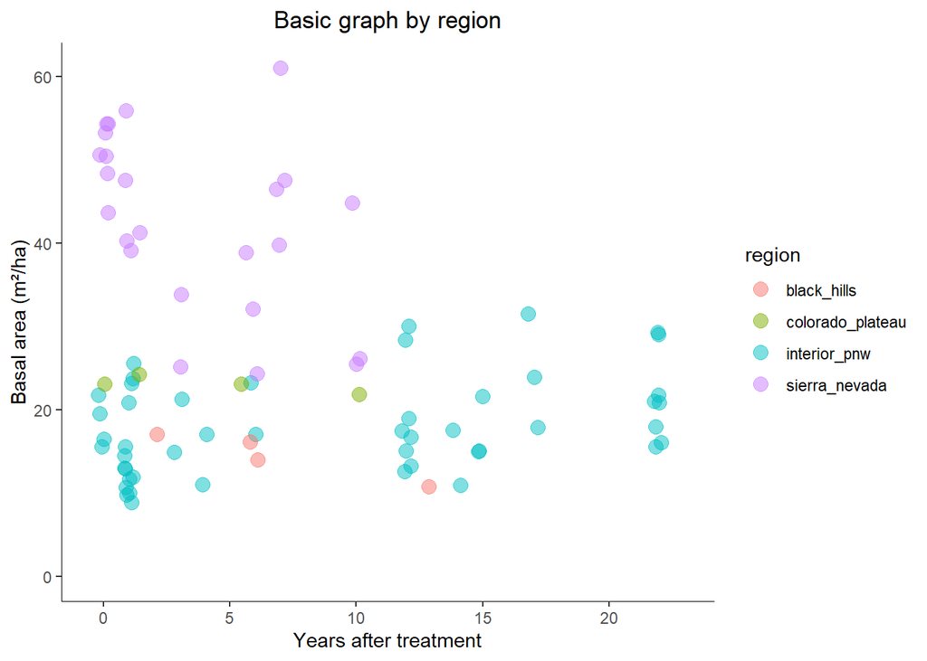

```r
ggplot(ba_ns, aes(x = years_post, y = value)) +
    geom_jitter(aes(color = region), size = 3.5, alpha = 0.5) +
    #scale_color_manual(values = treatment_colors) +
    coord_cartesian(xlim = c(-0.5, 23)) +
    expand_limits(y = 0) +
    ggtitle('Basic graph by region') +
    xlab('Years after treatment') +
    ylab('Basal area (m²/ha)') +
    simpletheme
```

I’d be inclined to get at more detail by faceting by treatment. We could consider cutting out the Crotteau (2018) study at the Lubrect, which would get rid of the beetle treatments and make presentation a lot simpler.

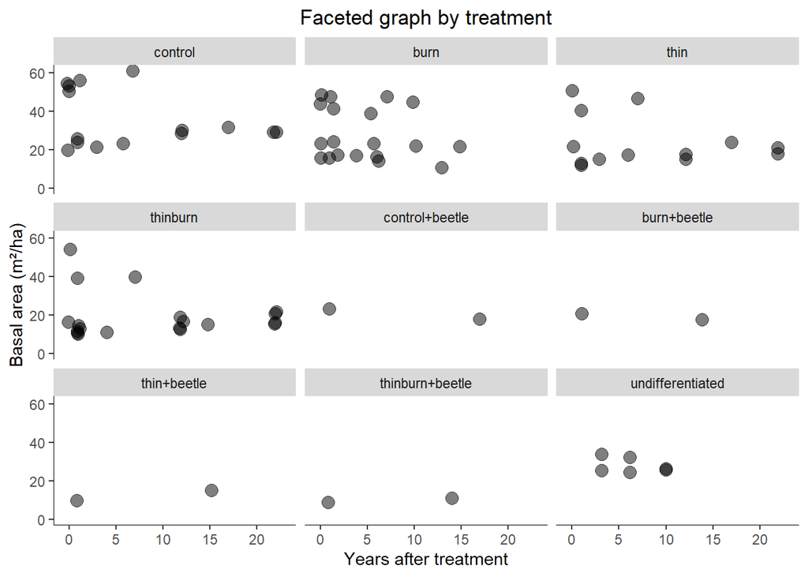

```r
ggplot(ba_ns, aes(x = years_post, y = value)) +
    geom_jitter(size = 3.5, alpha = 0.5) +
    facet_wrap(vars(treatment)) +
    #scale_color_manual(values = treatment_colors) +
    coord_cartesian(xlim = c(-0.5, 23)) +
    expand_limits(y = 0) +
    ggtitle('Faceted graph by treatment') +
    xlab('Years after treatment') +
    ylab('Basal area (m²/ha)') +
    simpletheme
```

And then we could color by region.

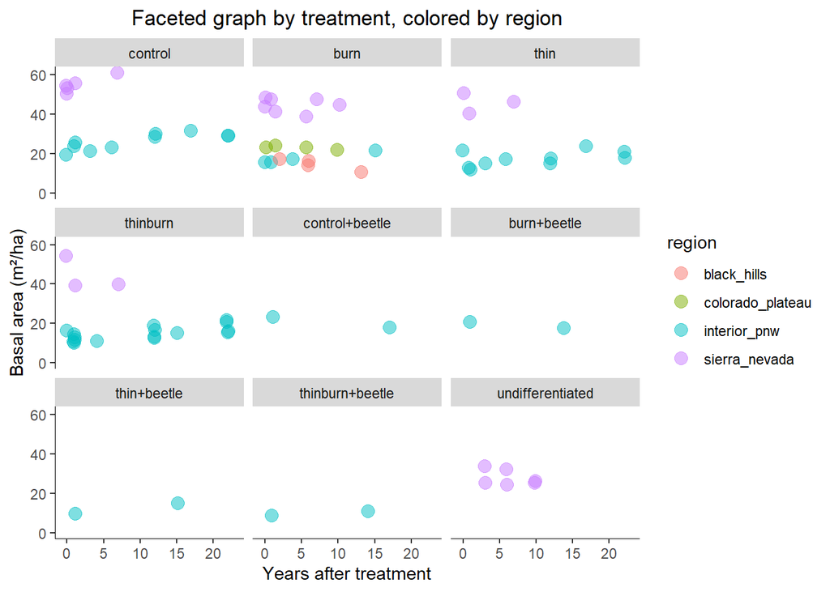

```r
ggplot(ba_ns, aes(x = years_post, y = value)) +
    geom_jitter(aes(color = region), size = 3.5, alpha = 0.5) +
    facet_wrap(vars(treatment)) +
    #scale_color_manual(values = treatment_colors) +
    coord_cartesian(xlim = c(-0.5, 23)) +
    expand_limits(y = 0) +
    ggtitle('Faceted graph by treatment, colored by region') +
    xlab('Years after treatment') +
    ylab('Basal area (m²/ha)') +
    simpletheme
```

And this is probably too much for a report, but we could add shapes for forest type, which helps show that the Sierra Nevada is dominating most of our mixed conifer sample (although our WA datasets will help balance it out a bit more).

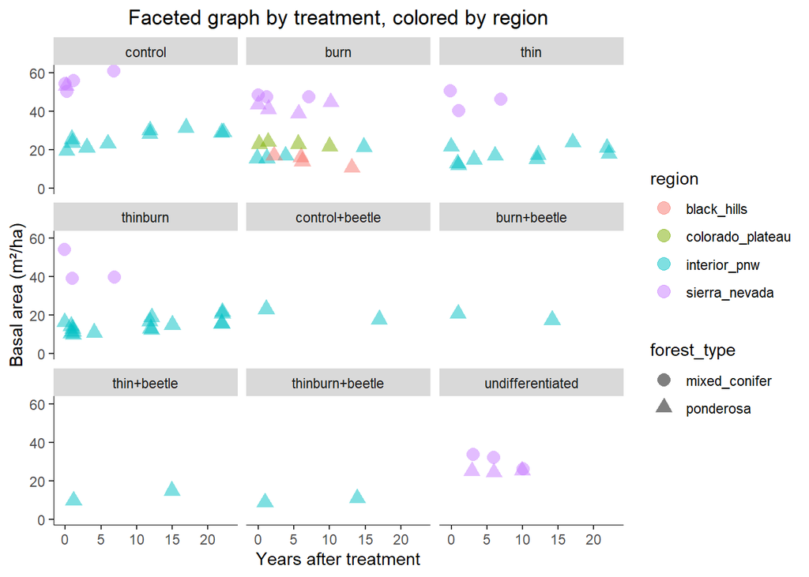

```r
ggplot(ba_ns, aes(x = years_post, y = value)) +
    geom_jitter(aes(color = region, pch = forest_type), size = 3.5, alpha = 0.5) +
    facet_wrap(vars(treatment)) +
    #scale_color_manual(values = treatment_colors) +
    coord_cartesian(xlim = c(-0.5, 23)) +
    expand_limits(y = 0) +
    ggtitle('Faceted graph by treatment, colored by region') +
    xlab('Years after treatment') +
    ylab('Basal area (m²/ha)') +
    simpletheme
```

We could present the same information without the Crotteau study, to simplify things.

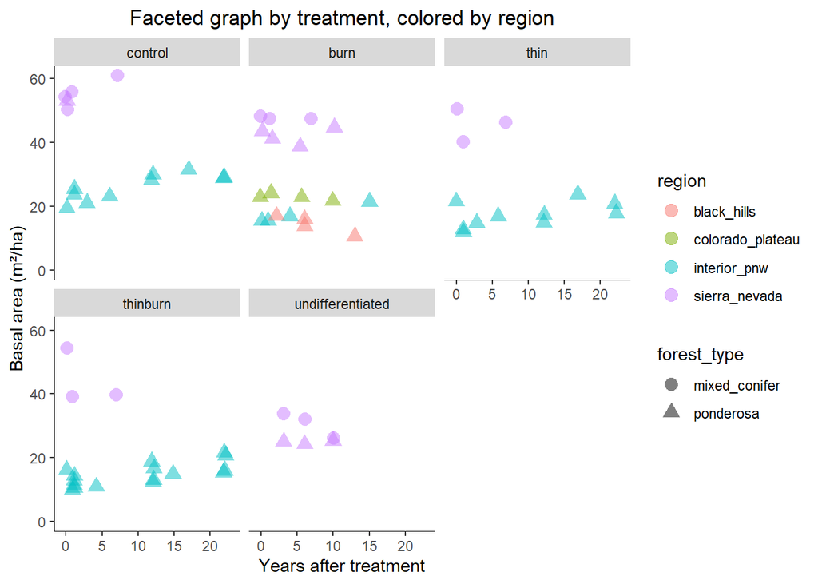

```r
gg_nc <- ba_ns %>%
  filter(treatment == 'control' | treatment == 'burn' | treatment == 'thin' |
           treatment == 'thinburn' | treatment == 'undifferentiated') %>%
  ggplot(aes(x = years_post, y = value)) +
    geom_jitter(aes(color = region, pch = forest_type), size = 3.5, alpha = 0.5) +
    facet_wrap(vars(treatment)) +
    #scale_color_manual(values = treatment_colors) +
    coord_cartesian(xlim = c(-0.5, 23)) +
    expand_limits(y = 0) +
    ggtitle('Faceted graph by treatment, colored by region') +
    xlab('Years after treatment') +
    ylab('Basal area (m²/ha)') +
    simpletheme
gg_nc
```

## Discussion points with Derek

Q1: How strongly do we want to try and draw conclusions from these types of graphs? Obviously I’ll couch any language I use, because these studies all have nuanced variation in treatment implementation, study design, ecological context, etc., that we can’t really capture here.

Q2: How in-depth do we present each Washington dataset, or do we just include it in the meta-analysis graph? The latter may be the better option from the standpoint of trying to publish the data later.

Q3: Can we send the study list to a couple people to see if it’s missing anything?

Here’s the proposed outline of the report. I propose to have a rough draft to you by Sunday night of this week, so you can look at it on Monday June 21st ahead of our meeting on Tuesday. It may be very rough in spots, but that way you can get a good sense of where I’m taking it before I polish it up too much.

1. Introduction
   - Big picture issues with lack of knowledge on fuels treatment longevity.
     - Fire scientists and pyrosilviculturalists advocating dramatic increase in pace and scale of treatment but we aren’t sure what the long term effects are and what an optimal maintentence treatment rotation might be.
     - Fuels treatments may decrease wood production value in long term by removing merchantable material in restoration phase.
     - We need both synthesis and further study of long term treatment effects, for understanding of treatment rotation, potential fire behavior, wood dynamics, biodiversity implications, and more.
   - Factors that likely affect longevity:
     - Productivity/forest type: growth and decomposition
     - Treatment type
     - Treatment intensity
   - Possible ways to define longevity and/or decide treatment rotation.
     - Buildup of fuels levels to pretreatment levels.
     - Threshold of expected and desired fire behavior.
     - Non fuel values that call for more frequent treatments than fuels longevity.
   - Our project:
     - Collected and synthesized data from three fuels treatment longevity studies in Washington.
     - Synthesized data from other longterm fuels treatment studies in the interior Western United States.
2. Methods
   - Description of data collection at Mission Creek, Colville NF, and NPS Fire Effects, with map.
   - Description of data collection for meta-analysis.
3. Results
   - Present one graph like those above, for each of the following core fuel and stand structure variables:
     - Fine woody surface fuel
     - Litter and duff mass
     - Average height to live crown
     - Canopy bulk density
     - Basal area
     - Density
     - Quadratic mean diameter
   - Note that not all studies report all these variables, and that for the stand structure variables, there are studies out there we didn’t include here because they didn’t include surface fuels. Most of our studies don’t report their shrub biomass.
4. Discussion and Conclusions